# Linear Regression: Model Specification, Comparison, and Interpretation

Predicting overall workplace ratings

Author

Jheanelle Walters

Published

November 6, 2026

## 1. Data and exploration

The analysis includes **30 departments**. Each observation is a department-level summary of employee responses, not an individual employee.

The data come from `attitude`, a dataset built into R that summarizes employee survey responses by department. The outcome variable is `rating`, the overall workplace rating, and the three predictors are `complaints` (handling of employee complaints), `learning` (opportunity to learn), and `raises` (pay increases).

### Descriptive statistics

Descriptive statistics for analysis variables

| variable | mean | sd | min | max |
| --- | --- | --- | --- | --- |
| rating | 64.63 | 12.17 | 40.00 | 85.00 |
| complaints | 66.60 | 13.31 | 37.00 | 90.00 |
| learning | 56.37 | 11.74 | 34.00 | 75.00 |
| raises | 64.63 | 10.40 | 43.00 | 88.00 |

### Distribution of overall rating

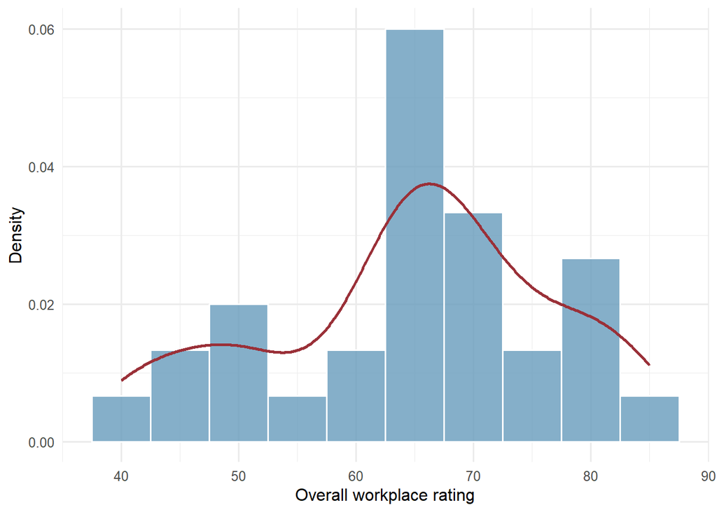

Distribution of overall workplace ratings

### Relationships between predictors and rating

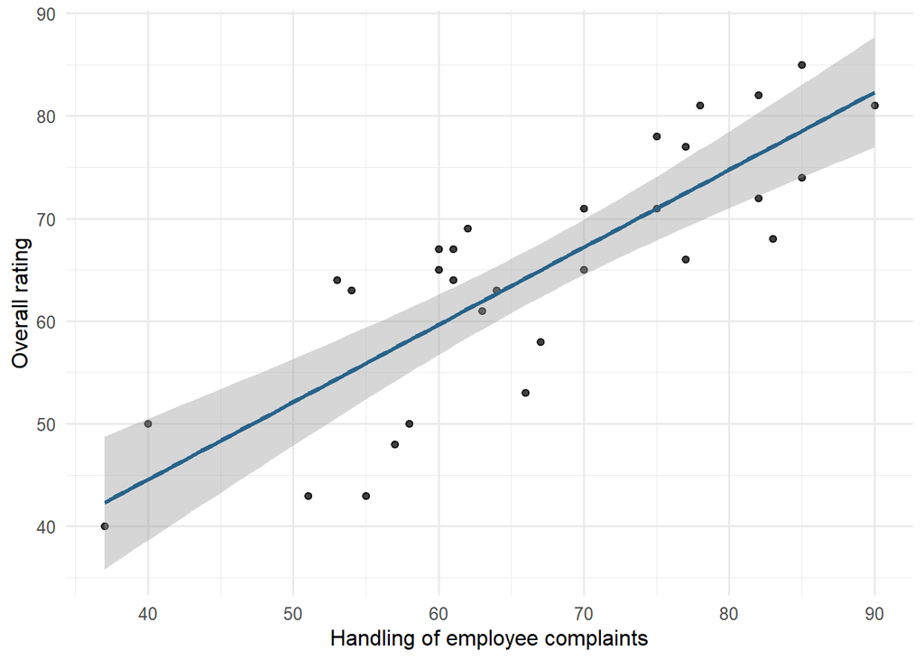

Relationship between complaint handling and overall rating

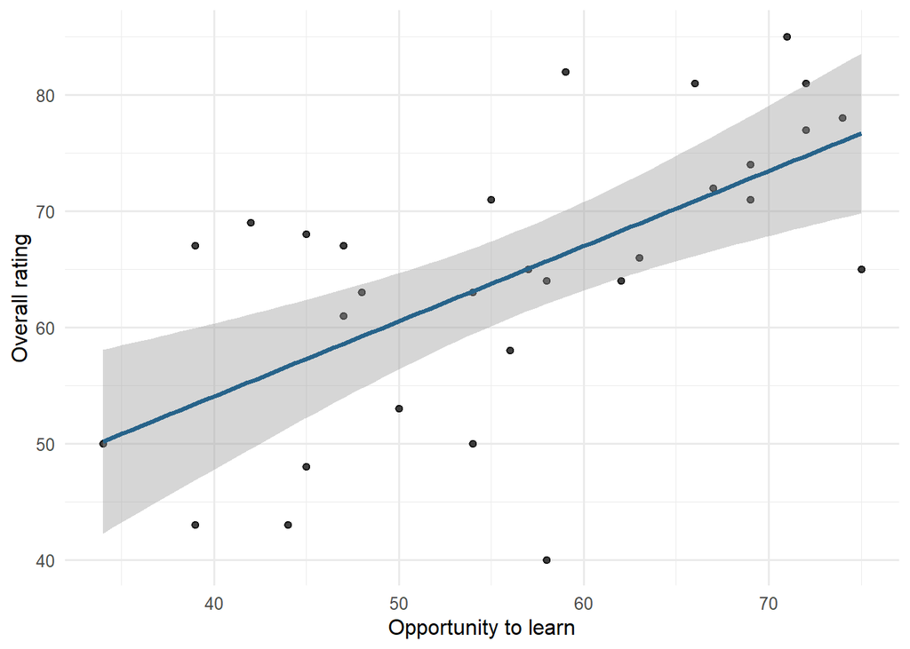

Relationship between learning opportunities and overall rating

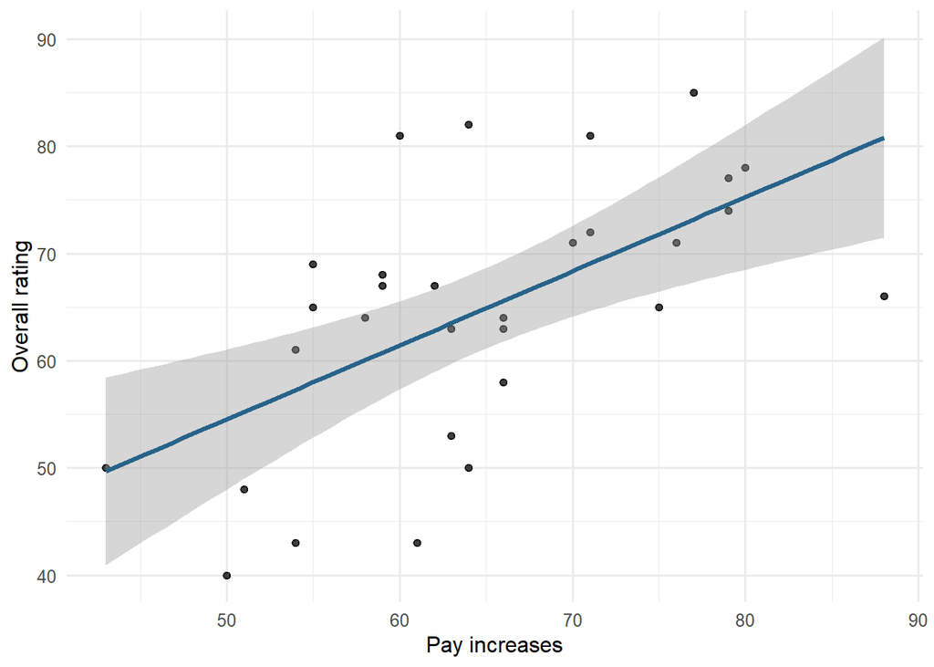

Relationship between pay increases and overall rating

### Exploratory patterns

The dataset includes 30 departments, with overall workplace ratings ranging from 40 to 85 (M = 64.63). The histogram shows ratings concentrated around 65, although there are some lower ratings around 45-50 and higher ratings closer to 80. All three predictors showed positive relationships with overall workplace ratings, and these relationships appeared to be approximately linear. Complaint handling showed the strongest relationship with overall ratings (r = .83), followed by learning opportunities (r = .62) and pay increases (r = .59). The predictors were also moderately correlated with one another (r = .60 to .67), which could be important when including them in the same model. One observation that stood out was a department with a high pay-increase score of approximately 88 but only a moderate overall rating. Overall, these findings were consistent with what I expected, particularly the stronger relationship between complaint handling and workplace ratings.

## 2. Specify competing models

### Predictions

Before running the models, I expected complaint handling, learning opportunities, and pay increases to all have positive relationships with overall workplace ratings. Of the three, I thought complaint handling would have the strongest association because employees may be more satisfied with their workplace when they feel their concerns are being heard and addressed fairly. I also expected learning opportunities to explain some additional variation in ratings beyond complaint handling, since opportunities for professional development represent a different aspect of the workplace experience. Similarly, I thought pay increases could contribute to overall ratings after accounting for complaints and learning, because employees may feel more valued when they are compensated fairly. However, I expected pay increases to have a smaller contribution, as some of its relationship with ratings might overlap with the other predictors. Based on these expectations, I predicted that each additional variable would improve the model, with complaint handling making the largest contribution.

We will estimate four nested models:

| Model | Formula | Purpose |
| --- | --- | --- |
| M0: Null | `rating ~ 1` | Baseline model |
| M1: Complaints | `rating ~ complaints` | Evaluate complaint handling |
| M2: Complaints + Learning | `rating ~ complaints + learning` | Additional contribution of learning |
| M3: Expanded | `rating ~ complaints + learning + raises` | Additional contribution of pay increases |

### How the complaints coefficient changes

In M1, the complaints coefficient (0.75) describes the association between complaint handling and overall rating with nothing else controlled: departments scoring one point higher on complaint handling were rated about 0.75 points higher overall, on average. In M2, the coefficient (0.64) is the association after holding learning opportunities constant. It is smaller, because part of the M1 association overlapped with learning. In M3, the coefficient (0.65) is the association holding both learning and pay increases constant. It is nearly unchanged from M2, so adding pay increases did not account for any further part of the complaints association. In all three models, complaint handling remained positively associated with rating.

## 3. Compare model performance

Overall model performance and incremental nested-model comparisons

| Model | R² | ΔR² | Adjusted R² | RMSE | Residual df | Nested df | Nested F | Nested p |
| --- | --- | --- | --- | --- | --- | --- | --- | --- |
| M0: Null | 0.000 | — | 0.000 | 11.968 | 29 | — | — | — |
| M1: Complaints | 0.681 | 0.681 | 0.670 | 6.756 | 28 | 1 | 60.726 | < .001 |
| M2: + Learning | 0.708 | 0.027 | 0.686 | 6.467 | 27 | 1 | 2.380 | 0.135 |
| M3: + Raises | 0.708 | 0.000 | 0.675 | 6.464 | 26 | 1 | 0.025 | 0.876 |

### Interpreting the model comparison

Although M3 explained the highest proportion of variation in workplace ratings (R² = .7083), the difference between M3 and M2 (R² = .7080) was extremely small. The greatest improvement occurred when complaint handling was added to the null model, explaining an additional 68.1% of the variation in ratings (p < .001). Adding learning opportunities increased the explained variation by only 2.7% (p = .135), while pay increases contributed almost nothing additional (ΔR² = .0003, p = .876). Neither of these improvements was statistically significant.

The adjusted R² increased from .670 in M1 to .686 in M2 but decreased to .675 in M3. This suggests that adding pay increases made the model more complex without meaningfully improving its performance. A similar pattern was seen with RMSE, which decreased substantially from 11.97 in the null model to 6.76 in M1. However, adding learning opportunities produced only a small further decrease, and adding pay increases had almost no effect. Overall, these findings suggest that complaint handling accounts for most of the variation explained by the models, while learning opportunities and pay increases provide limited additional information.

## 4. Evaluate regression diagnostics

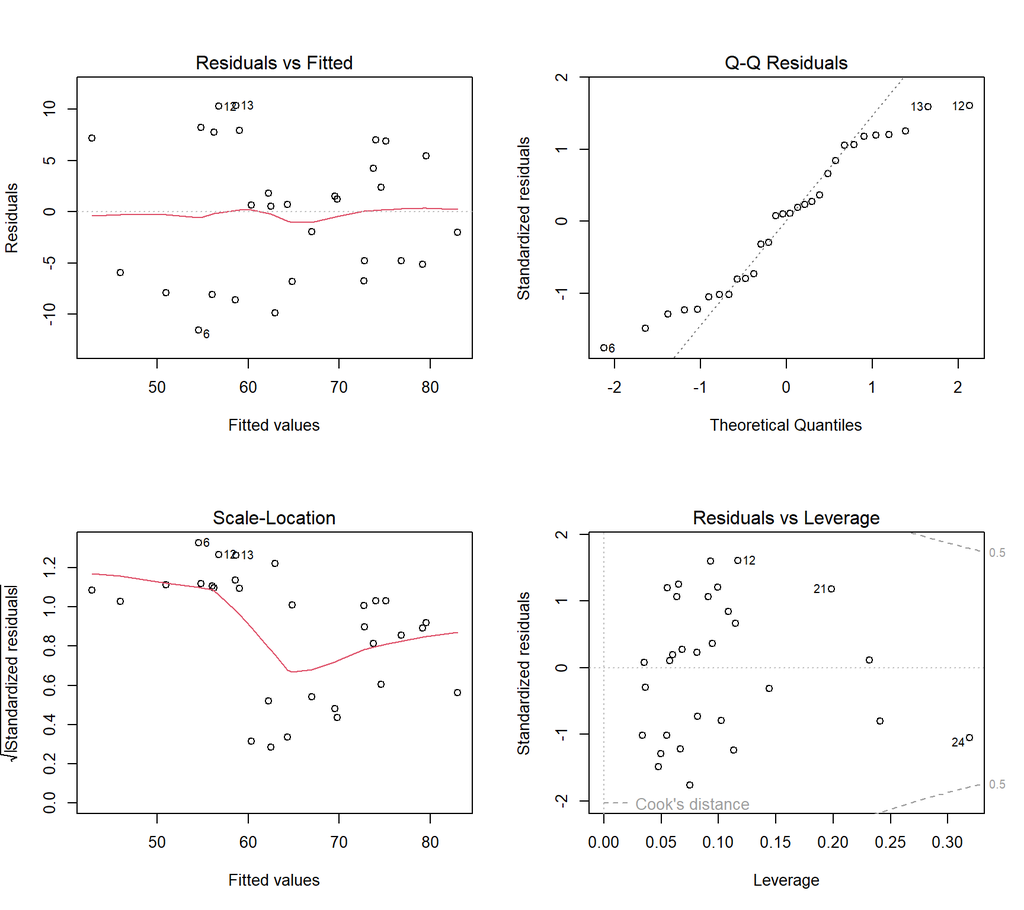

Regression diagnostic plots for the selected model

Variance inflation factors for the selected model

| Term | VIF | Tolerance |
| --- | --- | --- |
| complaints | 1.55 | 0.64 |
| learning | 1.55 | 0.64 |

The residuals-versus-fitted plot did not show any obvious curved patterns, and the smoothed line remained close to zero. This suggests that a linear model is reasonable for these data. The normal Q-Q plot also showed that most residuals followed the reference line fairly closely, although there were some small differences at the extremes. The Shapiro-Wilk test was not statistically significant (W = .945, p = .123), meaning there was no strong evidence that the residuals differed from a normal distribution. However, the small sample size should be considered when interpreting this result.

The scale-location plot showed some differences in the spread of residuals, particularly at lower fitted values, but there was no obvious funnel-shaped pattern to suggest a major issue with unequal variance. In the residuals-versus-leverage plot, department 24 had the highest leverage but a relatively small residual. Its Cook’s distance was 0.17, which was below the commonly used thresholds of 0.5 and 1, suggesting that it did not have an unusually large influence on the model. The variance inflation factors were also low (VIF = 1.55 for both predictors), indicating that multicollinearity was not a major concern. Overall, the diagnostic results did not identify any serious problems with the model assumptions, so I have reasonable confidence in using this model to interpret the associations. However, because the sample included only 30 departments, these findings should be interpreted cautiously.

## 5. Model selection

### Why this model

I selected M2, which includes complaint handling and learning opportunities, as the final model. The model comparisons showed that adding complaint handling significantly improved model fit compared with the null model (F = 60.7, p < .001). In contrast, adding learning opportunities (ΔR² = 0.027, p = .135) or pay increases (ΔR² = 0.0003, p = .876) did not lead to statistically significant improvements.

Despite this, M2 had the highest adjusted R² (0.686) and a slightly lower RMSE (6.47) than M1 (6.76). I decided against M3 because pay increases explained almost no additional variation and resulted in a lower adjusted R² (0.675). Although learning opportunities did not significantly improve the model, I chose to keep this predictor because it was relevant to my initial expectations and only added one additional variable. The diagnostic results also did not suggest any major concerns with M2, and the model remains easy to interpret, because each of its two predictors can be read directly in rating points. However, M1 would still be a reasonable alternative for someone who preferred a simpler model.

### Coefficient table

Unstandardized regression coefficients for the selected model

| Predictor | Estimate | SE | 95% CI lower | 95% CI upper | p |
| --- | --- | --- | --- | --- | --- |
| (Intercept) | 9.871 | 7.061 | −4.618 | 24.359 | 0.174 |
| complaints | 0.644 | 0.118 | 0.400 | 0.887 | < .001 |
| learning | 0.211 | 0.134 | −0.065 | 0.487 | 0.128 |

### Interpreting the coefficients

After accounting for learning opportunities (that is, holding them constant), a one-point increase in complaint-handling scores was associated with a predicted increase of approximately 0.64 points in overall workplace ratings (95% CI [0.40, 0.89], p < .001). Since the confidence interval does not include zero, this provides evidence of a positive association between complaint handling and workplace ratings.

For learning opportunities, a one-point increase was associated with a predicted increase of approximately 0.21 points in overall workplace ratings after accounting for complaint handling (95% CI [-0.06, 0.49], p = .128). Although this relationship was positive, it was not statistically significant, and the confidence interval included zero. Therefore, there is more uncertainty about the contribution of learning opportunities compared with complaint handling.

It is also important to consider that these scores represent the percentage of favourable responses within each department. Therefore, a one-point increase in a predictor represents a one-percentage-point increase in favourable employee responses.

### Model performance

Overall performance of the selected model

| Model | R² | Adjusted R² | RMSE |
| --- | --- | --- | --- |
| M2: + Learning | 0.708 | 0.686 | 6.467 |

The selected model explained approximately 70.8% of the variation in workplace ratings across the 30 departments (R² = .708), with an adjusted R² of .686. The RMSE was 6.47, suggesting that the model’s predicted ratings typically differed from the actual ratings by approximately 6.47 points. However, this only reflects how well the model fits the departments included in the analysis and does not necessarily indicate how well it would predict ratings for other departments.

## 6. Discussion and limitations

The results suggest that complaint handling was the strongest predictor of overall workplace ratings. When included on its own, it explained approximately 68% of the variation in ratings and was the only predictor that significantly improved model fit. Although learning opportunities explained a small amount of additional variation, this improvement was not statistically significant. Pay increases contributed almost no additional explanatory value once complaint handling and learning opportunities were included. However, this does not necessarily mean that learning opportunities or pay increases are unimportant. Because the predictors were moderately correlated with one another (r = .60 to .67), some of the variation associated with learning and pay increases may already have been explained by complaint handling.

There are also several limitations to consider. First, the analysis included only 30 departments, which limits statistical power and increases uncertainty in the estimates. This is particularly noticeable for learning opportunities, which had a relatively wide confidence interval. Another limitation is that the data represent department-level averages rather than individual employee responses, so the findings cannot necessarily be applied to individual employees. Additionally, because the data are observational, the results only demonstrate associations and cannot establish that any of these factors directly cause changes in workplace ratings.

Finally, although I selected M2 because of its slightly better adjusted R² and RMSE, the improvement over M1 was not statistically significant. Therefore, selecting the simpler M1 model would also be reasonable. The results also reflect model performance using the same data on which the models were fitted, so further evaluation would be needed to determine how accurately the model predicts ratings for new departments.